# Police killing data scraping

Adela Sobotkova

20 July 2020

# Goal

I want to be able to analyse the data on police shootings from 2013-2020 (july 2020) that are nicely collated on summarised on https://killedbypolice.net/.

# Challenge

The data resides in the HTML table that has notoriously messy headers and tags. Look and weep:

[figure not shown]

But fear not! There’s nothing that R can’t fix in a blink of an eye. And here’s how:

Great guidelines to finding the right tags are in [rvest tutorial on Youtube](https://www.youtube.com/watch?v=4IYfYx4yoAI)

# Solution

First, load a handful of classic R packages:

{rvest} for web-scraping {dplyr} for data-wrangling {tidyr} for data transformation {stringr} for string manipulation {janitor} for clean headers that your OCD will love you for

```r
library(rvest)
library(dplyr)
library(tidyr)
library(stringr)
library(janitor)
```

## Scrape the data

Next, learn how scrape the content of the website and extract the HTML table:

```r
url <- "https://killedbypolice.net/kbp2020"
# scrape the website
url_html <- read_html(url)


# Option 1 extract the HTML table individual row tags <tr> >> BUT this straightjackets each row into an element in a character vector, which would require extra cleaning
whole_table <- url_html %>%
 html_nodes("tr") %>%
 html_text(trim = FALSE)

#2 extract the HTML table individual datapoint tags <td>  >> BUT this creates a character element out of each table cell, which would require extra cleaning
whole_table <- url_html %>%
 html_nodes("td") %>%
 html_text(trim = FALSE)

# extract the HTML table through the <table> tag >> this creates a list instead of dataframe, but we can unlist a list and coerce it into a dataframe, so vaersgo!
whole_table <- url_html %>%
 html_nodes("table") %>%
 html_table()  #str(whole_table) turns out to be a list

new_table <- do.call(cbind,unlist(whole_table, recursive = FALSE)) # we unlist and combine the individual elements as columns, following https://stackoverflow.com/questions/16300344/how-to-flatten-a-list-of-lists
head(new_table) # ok, looks good, too bad it took 2 hours
```

```
##      Date         Name                             Age  Gender Race State *
## [1,] "2020-01-01" "Derrick A. Elseth"              "24" "M"    "W"  "VA"  "G"
## [2,] "2020-01-01" "Teddy James Maverick Varner"    "29" "M"    ""   "OR"  "G"
## [3,] "2020-01-01" "Gerardo Antonio Conchas-Bustas" "20" "M"    "O"  "CO"  "K"
## [4,] "2020-01-01" "Gabriel Strickland"             "25" "M"    "W"  "CA"  "T"
## [5,] "2020-01-02" "Jeffery Dale Millsap"           "26" "M"    "W"  "MO"  "G"
## [6,] "2020-01-02" "Stanley Hayes"                  "69" "M"    ""   "OR"  "G"
##      Source
## [1,] "wric.com, nbc12.com"
## [2,] "kobi5.com, kdrv.com, kdrv.com"
## [3,] "denverpost.com, kdvr.com"
## [4,] "sacbee.com"
## [5,] "kansascity.com, kctv5.com"
## [6,] "kxl.com, kptv.com, oregonlive.com"
```

```r
# https://stackoverflow.com/questions/4227223/convert-a-list-to-a-data-frame
```

## Automate the scraping!

Now, lets write a function to read the tables for all the sequential websites

```r
# First create the function to scrape tables

scrape_police_death <- function(website){
    url <- read_html(website)
    annual_table <- url %>%
            html_nodes("table") %>%
            html_table()  #str(whole_table) turns out to be a list
  annual_table <- do.call(cbind,unlist(annual_table, recursive = FALSE))
 }

# Test that the function works

table2018 <- scrape_police_death("https://killedbypolice.net/kbp2018")


# Now write a loop to apply it to sequential years from 2018 on

mastertable=NULL  # we need to create an empty container for results

for (year in 2013:2020){  # here we create a loop to iterate over the years
    print(year)
    url <- "https://killedbypolice.net/kbp"
    website <- paste0(url,year)  # here we bind the year to the website
    annual_table <- scrape_police_death(website) # here we apply the function
    mastertable <- rbind(mastertable, annual_table) # we add the results from the given year to our master dataset
    }
```

```
## [1] 2013
## [1] 2014
## [1] 2015
## [1] 2016
## [1] 2017
## [1] 2018
## [1] 2019
## [1] 2020
```

```r
head(mastertable,2)
```

```
##      Date         Name                Age  Gender Race State *
## [1,] "12/31/2013" "James M. Eshelman" "54" "M"    ""   "WA"  "G"
## [2,] "12/31/2013" "Dontae Hayes"      "20" "M"    "B"  "CA"  "G"
##      Source
## [1,] "columbiabasinherald.com"
## [2,] "blog.pe.com"
```

```r
tail(mastertable)
```

```
##         Date         Name                        Age  Gender Race State *
## [5650,] "2020-07-22" "An unidentified person"    NA   "F"    ""   "FL"  "G"
## [5651,] "2020-07-23" "An unidentified person"    NA   "M"    ""   "MI"  "G"
## [5652,] "2020-07-25" "Christopher Poor"          "49" "M"    "W"  "OK"  "U"
## [5653,] "2020-07-26" "Samuel Solomon Cochran Jr" "22" "M"    ""   "NC"  "K"
## [5654,] "2020-07-27" "David Earl Brooks"         "45" "M"    ""   "NC"  "G"
## [5655,] "2020-07-28" "An unidentified person"    NA   "M"    ""   "NC"  "G"
##         Source
## [5650,] "tampabay.com, wfla.com"
## [5651,] "detroitnews.com, detroitnews.com"
## [5652,] "kfor.com, koco.com"
## [5653,] "myfox8.com, wfmynews2.com"
## [5654,] "wral.com, ncadvertiser.com"
## [5655,] "wyff4.com, wspa.com"
```

The dataset is currently a matrix, which is not super convenient, so let’s cast it to tibble and then clean it up

```r
mastertable <- as_tibble(mastertable)
```

## Revert Age from factor and label Method column

```r
data <- mastertable %>%
    mutate(Age = as.numeric(Age)) %>%
    rename(Method="*")
```

## Cleanup the dates with lubridate package and grepl()

First, lets look how well structured our Date column is

```r
mastertable$Date[c(70:80, 160:170)]
```

```
##  [1] "12/2/2013"  "12/1/2013"  "12/1/2013"  "12/1/2013"  "12/31/2014"
##  [6] "12/31/2014" "12/31/2014" "12/31/2014" "12/31/2014" "12/31/2014"
## [11] "12/31/2014" "12/3/2014"  "12/2/2014"  "12/2/2014"  "12/2/2014"
## [16] "12/1/2014"  "12/1/2014"  "12/1/2014"  "2015-01-02" "2015-01-02"
## [21] "2015-01-03" "2015-01-04"
```

Clearly there are inter-annual differences in how the date was formatted.

```r
library(lubridate)
data <- data %>%
    mutate(Date =
            case_when(
                grepl("201[34]",Date) ~ mdy(Date),
                !grepl("201[34]",Date)~ ymd(Date)))
data <- data %>%
    mutate(Year = year(Date))

tail(data$Year)
```

```
## [1] 2020 2020 2020 2020 2020 2020
```

```r
class(data$Date)
```

```
## [1] "Date"
```

```r
length(which(is.na(data$Date)))
```

```
## [1] 0
```

Now that the data looks half decent, we can export it to a file

```r
write.csv(data,"data/policekillings.csv")
```

## Analyze!

The most common age to be killed by police is in the late twenties and early thirties, and this has not changed much over time.

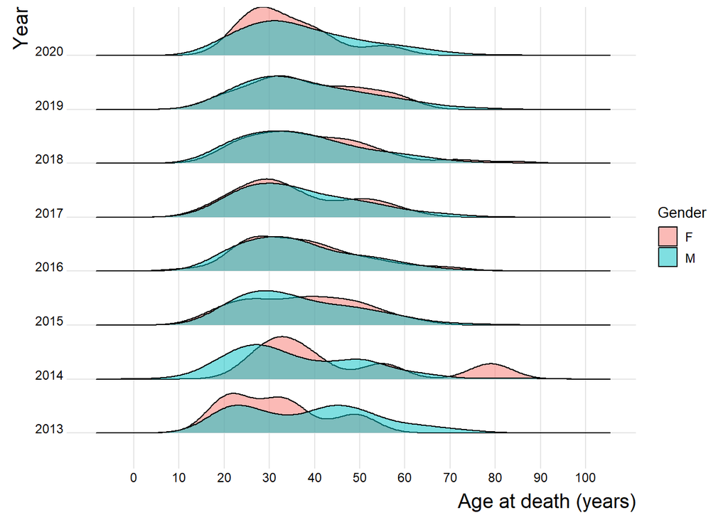

```r
library(ggplot2)
library(ggridges)


data %>%
  filter(Gender %in% c("F", "M", "T")) %>%
  filter(!is.na(Year)) %>%
  ggplot(aes(x = Age,
             y = factor(Year),
             fill = Gender)) +
  geom_density_ridges(alpha = 0.5,
                      scale = 0.9)  +
  theme_ridges(font_size = 10) +
  scale_x_continuous(breaks = seq(0, 100, 10),
                     labels = seq(0, 100, 10)) +
  xlab("Age at death (years)") +
  ylab("Year") +
  theme(axis.title = element_text(size = 14))
```

We can see, however, that with time the age is centering more around 30 rather than 20.

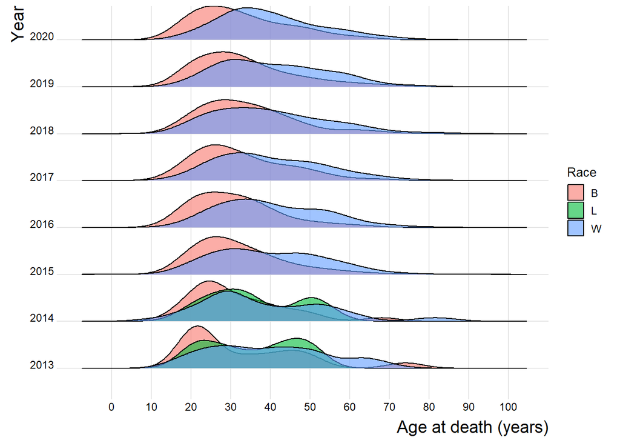

```r
data %>%
  filter(Race %in% c("B", "W", "L")) %>%
  filter(!is.na(Year)) %>%
  ggplot(aes(x = Age,
             y = factor(Year),
             fill = Race)) +
  geom_density_ridges(alpha = 0.6,
                      scale = 0.9)  +
  theme_ridges(font_size = 10) +
  scale_x_continuous(breaks = seq(0, 100, 10),
                     labels = seq(0, 100, 10)) +
  xlab("Age at death (years)") +
  ylab("Year") +
  theme(axis.title = element_text(size = 14))
```

By far the most common way that people are killed by police is with a gun. Deaths by vehicle involve women more often than men.

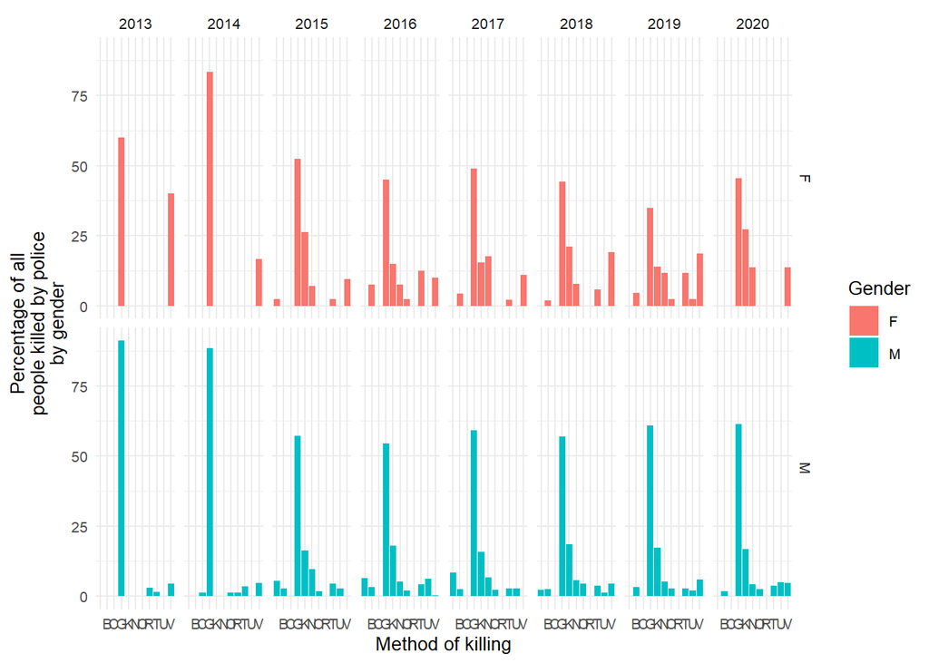

```r
data %>%
  filter(!is.na(Year)) %>%
  filter(Method != "NA") %>%
  filter(Gender %in% c("M", "F", NA)) %>%
  group_by(Year,
           Gender,
           Method) %>%
  tally() %>%
  mutate(perc = n / sum(n) * 100)  %>%
  ggplot(aes(Method,
             perc,
             fill = Gender)) +
  geom_col() +
  facet_grid(Gender~Year) +
  theme_minimal(base_size = 10) +
  xlab("Method of killing") +
  ylab("Percentage of all\npeople killed by police\nby gender")
```

## Map casualties by state

In 2016, the state with the largest number of people killed by police was California.

```r
#install.packages(c("statebins", "viridis"))
library(statebins) # using GitHub version
library(viridis)
# we need to convert state abbreviations to state names for the statebins function
state_abb <- data_frame(state_name = state.name,
                        state_abb = state.abb)
# we need to add the state popluations so we can get a proportion of people in each state
# we got this from https://www2.census.gov/programs-surveys/popest/tables/2010-2016/state/totals/nst-est2016-01.xlsx
state_populations <- readr::read_csv("data-raw/nst-est2016-01.csv")
# clean it a little
state_populations <-
  state_populations %>%
  mutate(state_name = gsub("\\.", "", X__1)) %>%
  left_join(state_abb)
# compute deaths by state and as deaths per 1000 people in each state
by_state <- data %>%
  filter(Year == 2016) %>%
  group_by(State) %>%
  tally() %>%
  left_join(state_abb, by = c('State' = 'state_abb')) %>%
  filter(!is.na(state_name)) %>%
  left_join(state_populations) %>%
  mutate(per_n_people = (n / `2016`) * 1000000)
```

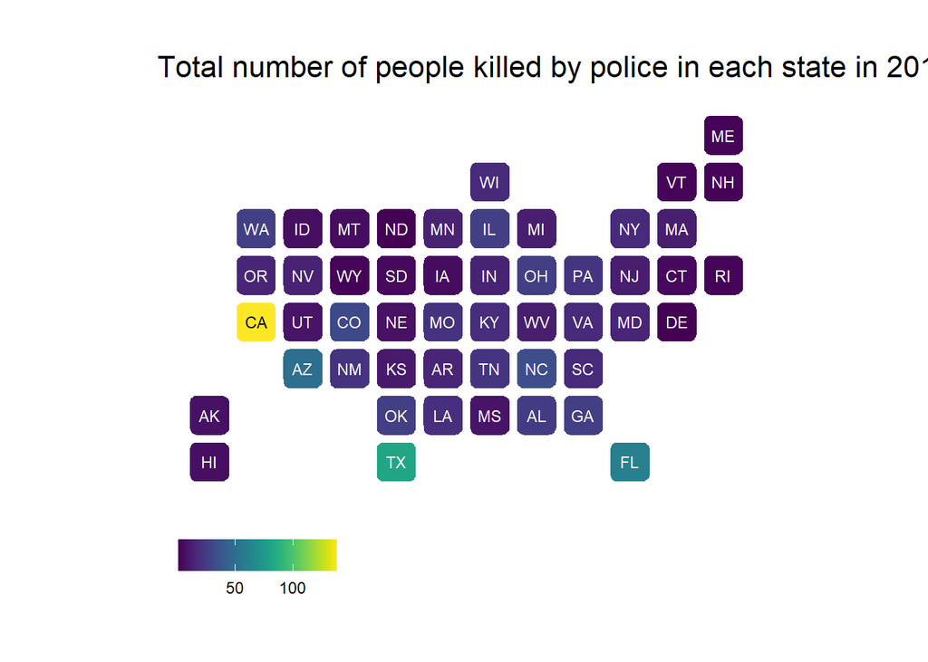

```r
# plot 'statebin' style map
ggplot(by_state,
       aes(state = state_name,
           fill = n)) +
  geom_statebins() +
  coord_equal() +
  scale_fill_viridis() +
  theme_statebins() +
  labs(title = "Total number of people killed by police in each state in 2016") +
  theme(legend.title=element_blank())
```

The difference between 2016 and 2019 is hardly visible, with exception of Texas. Downloaded on 20 July from https://www2.census.gov/programs-surveys/popest/tables/2010-2019/state/asrh/

```r
state_population19 <- readr::read_csv("data-raw/sc-est2019-alldata5.csv")
# clean it a little
state_pop17_19 <- state_population19 %>%
    group_by(NAME) %>%
    summarize(pop2017= sum(POPESTIMATE2017), pop2018 = sum(POPESTIMATE2018), pop2019=sum(POPESTIMATE2019)) %>%
    rename(state_name = NAME)
state_pop17_19 %>%
    select(state_name, pop2017) %>%
    glimpse()
```

```
## Observations: 51
## Variables: 2
## $ state_name <chr> "Alabama", "Alaska", "Arizona", "Arkansas", "California"...
## $ pop2017    <dbl> 19848340, 3195164, 29037264, 12270976, 164140492, 231887...
```

```r
# compute deaths by state and as deaths per 1000 people in each state
by_state19 <- data %>%
  filter(Year == 2019) %>%
  group_by(State) %>%
  tally() %>%
  left_join(state_abb, by = c('State' = 'state_abb')) %>%
  filter(!is.na(state_name)) %>%
  left_join(state_pop17_19) %>%
  mutate(per_n_people = (n / `pop2019`) * 1000000)
```

[figure not shown]

[output not shown]

[figure not shown]

```r
# plot 'statebin' style map
ggplot(by_state19,
       aes(state = state_name,
           fill = n)) +
  geom_statebins() +
  coord_equal() +
  scale_fill_viridis() +
  theme_statebins() +
  labs(title = "Total number of people killed by police in each state in 2019") +
  theme(legend.title=element_blank())
```

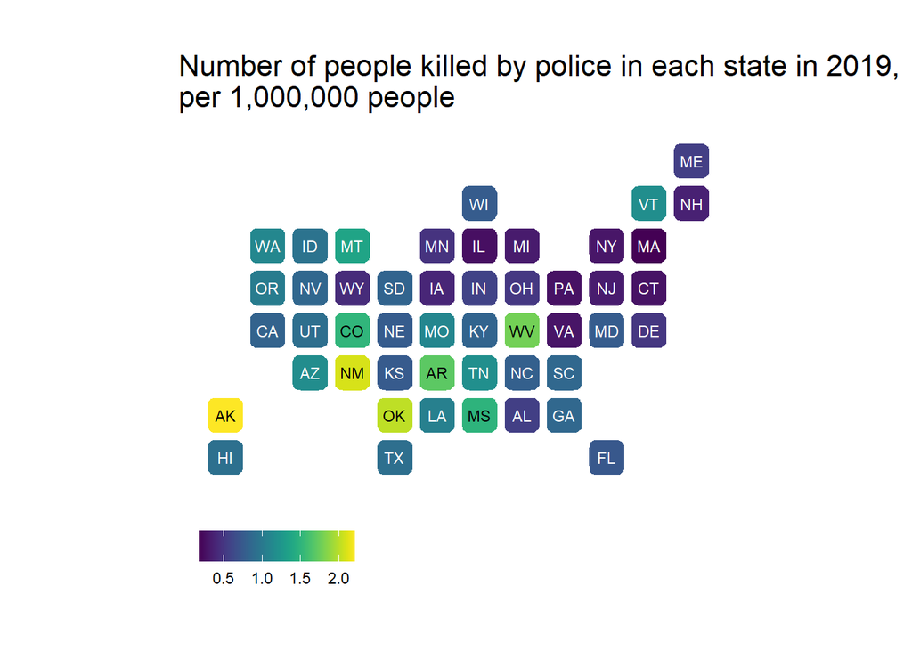

```r
ggplot(by_state19,
       aes(state = state_name,
           fill = per_n_people)) +
  geom_statebins() +
  coord_equal() +
  scale_fill_viridis() +
  theme_statebins() +
  labs(title = "Number of people killed by police in each state in 2019,\nper 1,000,000 people")  +
  theme(legend.title=element_blank())
```